# single-c fit overview

Pawel Sadlowski

single-c was fit to data preprocessed with RP method C and limited to 10 most popular items. Price shock was left unscaled.

v3b1_single model was used with k=30

Runtime ranged 3.6-3.8h and max memory use was not measured. RDS fit file measures approx. 900MB.

# Sampling problems

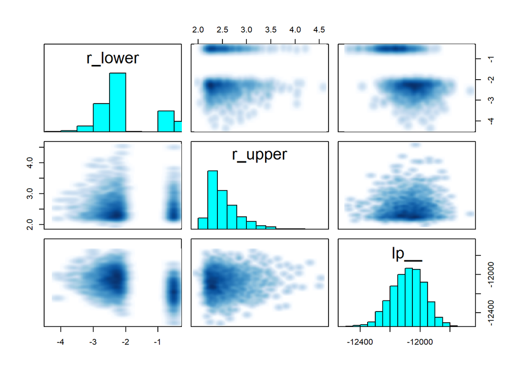

```r
if ( het_r) {
  pairs( fit, pars = c( 'sigma_lower', 'sigma_upper', 'lp__'))
} else {
  pairs( fit, pars = c( 'r_lower', 'r_upper', 'lp__'))
}
```

There is a suprising pattern in the lower threshold value with a clear space of low (zero) density

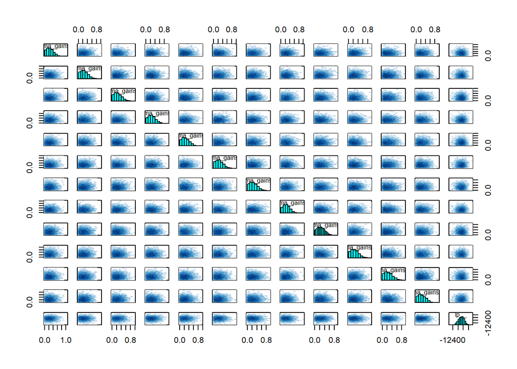

```r
pairs( fit, pars = c( 'sigma_gains', 'lp__'))
```

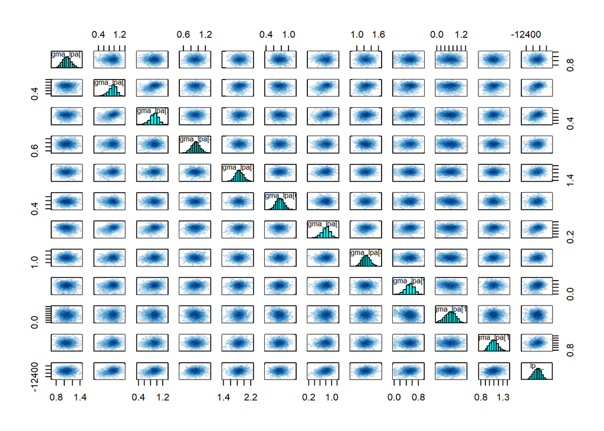

```r
pairs( fit, pars = c( 'sigma_lpa', 'lp__'))
```

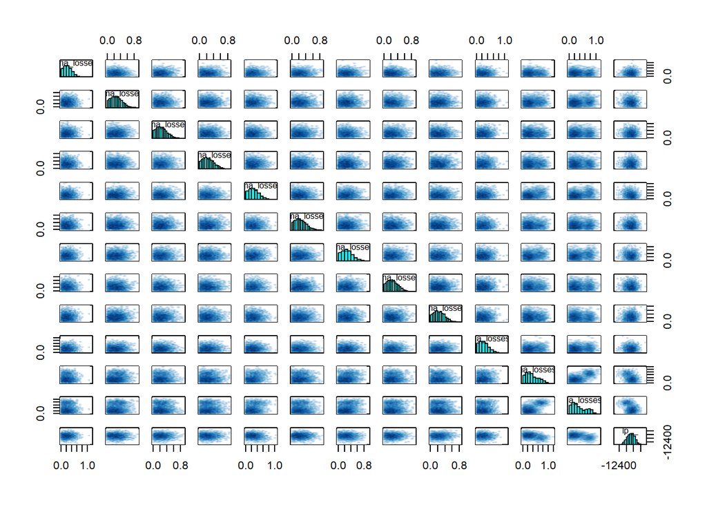

```r
pairs( fit, pars = c( 'sigma_losses', 'lp__'))
```

# $\hat{R}$

```r
rhat %>%
  is.na() %>% which() %>% names() %>%
  vapply( function( name) {
    a <- unlist( regmatches( ., gregexpr( '\\d+', .)))
    as.numeric( a[1]) > as.numeric( a[2])
  }, FUN.VALUE = TRUE) %>% any()
```

```
## [1] FALSE
```

NA values in $\hat{R}$ only for upper triangle in L matrices (values fixed at 0).

```r
rhat %>%
  `[`( !is.na( .)) %>% max()
```

```
## [1] 3.432611
```

Certain $\hat{R}$ values notably exceed commonly accepted limits.

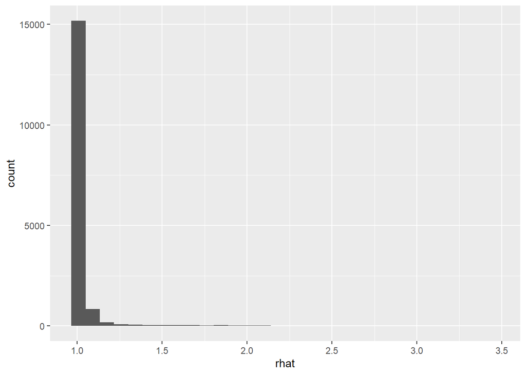

```r
ggplot() +
  geom_histogram( data = data.frame( rhat = rhat[!is.na( rhat)]), aes( x = rhat))
```

Relatively big values aren’t uncommon in this setup.

```r
which( rhat[!is.na( rhat)] > 1.03) %>% names()
```

```
##    [1] "delta_lpa[2,3]"      "delta_lpa[2,4]"      "delta_lpa[2,10]"
##    [4] "delta_lpa[2,11]"     "delta_lpa[2,12]"     "delta_lpa[2,14]"
##    [7] "delta_lpa[3,1]"      "delta_lpa[3,3]"      "delta_lpa[3,4]"
##   [10] "delta_lpa[3,8]"      "delta_lpa[3,10]"     "delta_lpa[3,12]"
##   [13] "delta_lpa[3,14]"     "delta_lpa[7,2]"      "delta_lpa[7,3]"
##   [16] "delta_lpa[7,4]"      "delta_lpa[7,6]"      "delta_lpa[7,9]"
##   [19] "delta_lpa[7,13]"     "delta_lpa[7,14]"     "delta_lpa[11,2]"
##   [22] "delta_lpa[11,11]"    "delta_lpa[11,14]"    "delta_losses[2,12]"
##   [25] "delta_losses[3,1]"   "delta_losses[3,3]"   "delta_losses[3,8]"
##   [28] "delta_losses[3,10]"  "delta_losses[3,11]"  "delta_losses[5,4]"
##   [31] "delta_losses[5,10]"  "delta_losses[5,14]"  "delta_losses[6,9]"
##   [34] "delta_losses[6,10]"  "delta_losses[7,3]"   "delta_losses[7,4]"
##   [37] "delta_losses[7,9]"   "delta_losses[7,13]"  "delta_losses[7,14]"
##   [40] "delta_losses[10,3]"  "delta_losses[10,4]"  "delta_losses[10,10]"
##   [43] "delta_losses[10,14]" "delta_losses[11,1]"  "delta_losses[11,2]"
```

[output cut: 753 more lines]

```r
if (het_r) {
  rhat[c( 'sigma_lower', 'sigma_upper', 'lp__')]
}
```

```r
which( rhat[!is.na( rhat)] > 1.03) %>% names() %>%
  `[`( grep( '(r_)|(beta_)', .)) %>%
  regmatches( ., regexpr( '\\d+', .)) %>%
  as.numeric() %>% unique() -> high_rhat
table( data$h_id)[high_rhat] %>% table()
```

```
## .
##  1  2  3  4  5  6  7  8  9 10 11 12 13 14 15 16 17 18 19 20 21 22 23 25 26 27
## 87 46 53 36 37 28 30 24 14 10 11  5 13  5  4  5  5  8  2  2  4  1  1  3  2  1
## 28 29 31 33 35 47
##  1  1  2  1  1  1
```

```r
data$N / data$H
```

```
## [1] 6.412162
```

On average, there are 6-7 observations per customer, which is definitely a low figure considering that there are 12 individual-specific parameters to be estimated. On the other hand, this probably shouldn’t contribute to bad mixing. It could also be caused by low variability in prices, I guess.

```r
all( data$h_id %in% high_rhat)
```

```
## [1] TRUE
```

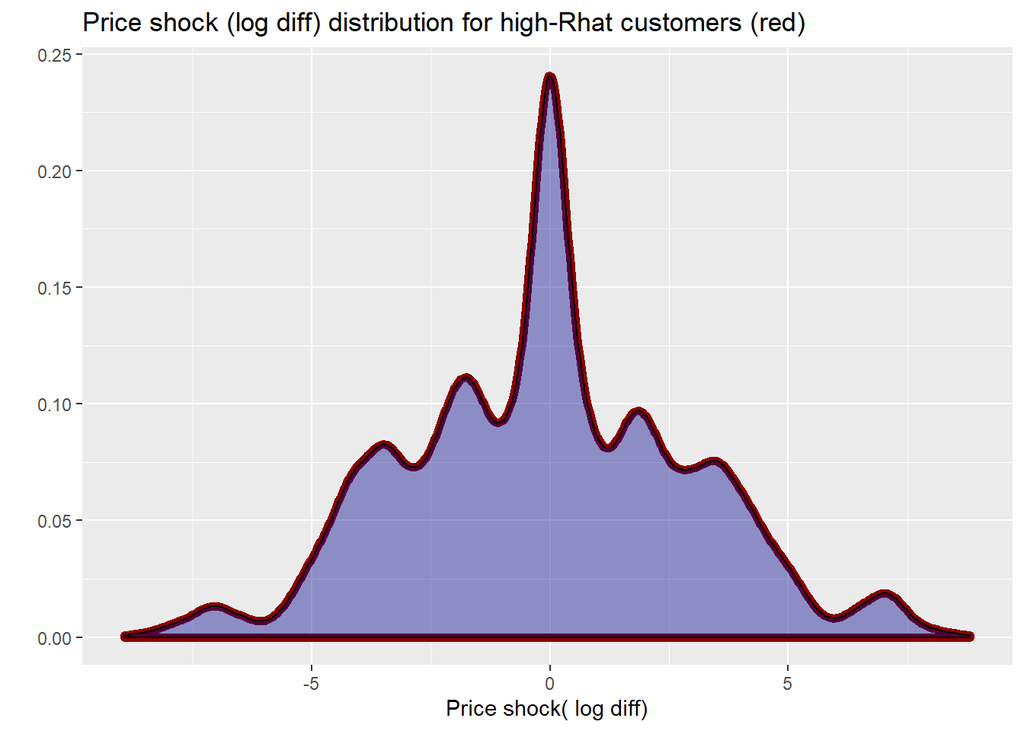

```r
ggplot( data.frame( ps = as.vector( data$ps[,data$h_id %in% high_rhat]))) +
  geom_density( aes( x = ps), color = 'darkred', lwd = 2) +
  geom_density( data = data.frame( x2 = as.vector( data$ps)), aes( x = x2),
                  fill = 'darkblue', alpha = 0.4) +
  ggtitle( 'Price shock (log diff) distribution for high-Rhat customers (red)') +
  xlab( 'Price shock( log diff)') + ylab( '')
```

The $high-\hat{R}$ customers don’t face a distorted distribution of price shocks.

```r
mean( rhat[!is.na( rhat)] > 1.03)
```

```
## [1] 0.1376487
```

```r
rm( high_rhat)
```

$\hat{R}$ was higher than 1.03 for approx. 14% of parameters, which is definitely not an acceptable portion

# Bulk ESS

```r
apply( posterior, 3, ess_bulk) %>% is.na() %>% which() %>% names() %>%
  vapply( function( name) {
    a <- unlist( regmatches( ., gregexpr( '\\d+', .)))
    as.numeric( a[1]) > as.numeric( a[2])
  }, FUN.VALUE = TRUE) %>% any()
```

```
## [1] FALSE
```

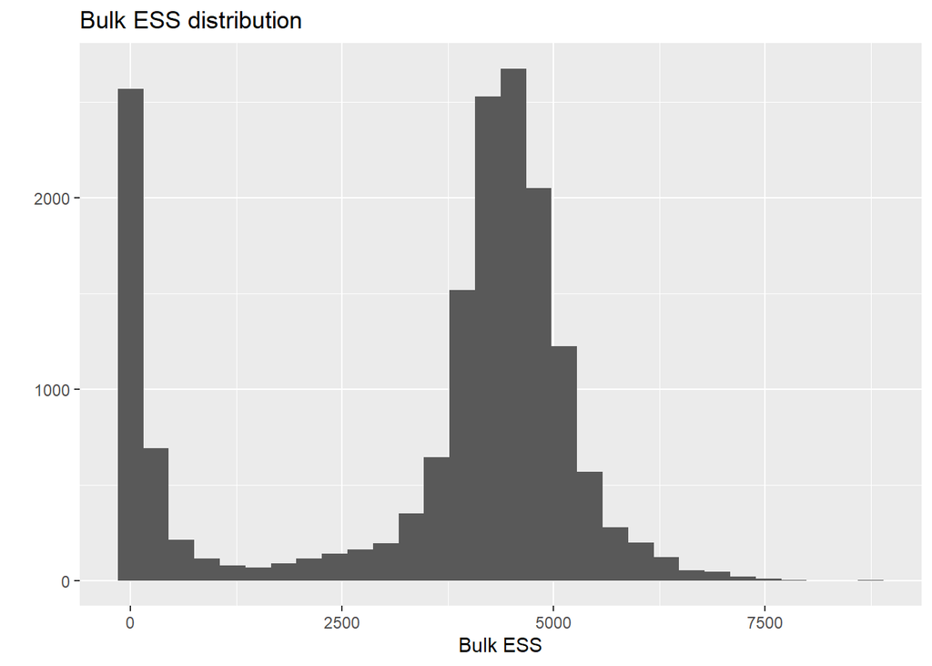

```r
ggplot( data.frame( ess = ess)) +
  geom_histogram( aes( x = ess)) +
  ggtitle( 'Bulk ESS distribution') +
  xlab( 'Bulk ESS') + ylab( '')
```

It is a clearly visible problem in the lower tail of the bulk ESS distribution

```r
sprintf( '%.2f pct parameters with bulk ESS lower than 1k and %.2f pct lower than 100',
         mean( ess < 1e3) * 100, mean( ess < 100) * 100)
```

```
## [1] "21.37 pct parameters with bulk ESS lower than 1k and 13.07 pct lower than 100"
```

# Tail ESS

```r
apply( posterior, 3, ess_tail) %>% is.na() %>% which() %>% names() %>%
  vapply( function( name) {
    a <- unlist( regmatches( ., gregexpr( '\\d+', .)))
    as.numeric( a[1]) > as.numeric( a[2])
  }, FUN.VALUE = TRUE) %>% any()
```

```
## [1] FALSE
```

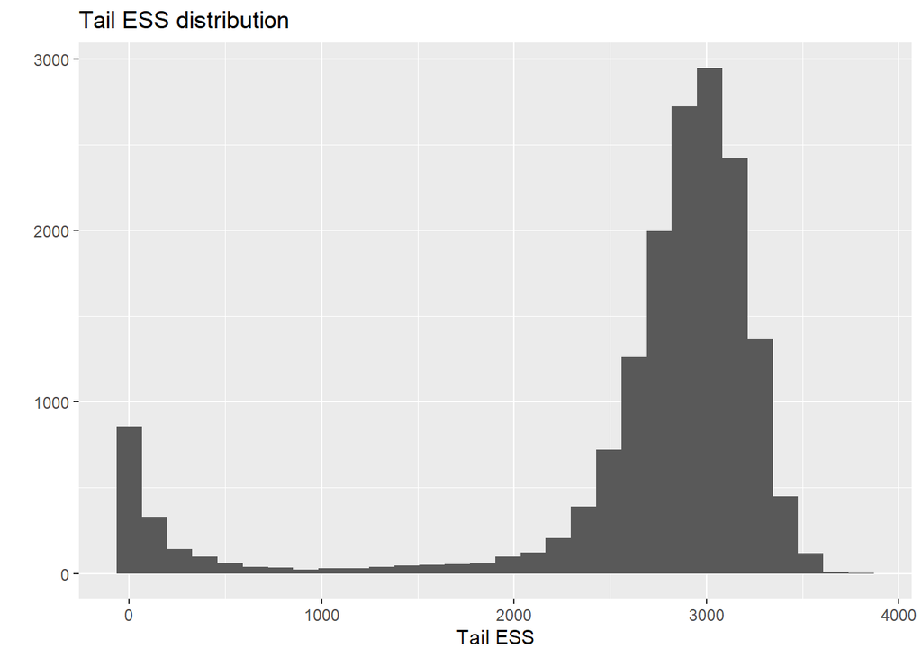

```r
ggplot( data.frame( ess = ess)) +
  geom_histogram( aes( x = ess)) +
  ggtitle( 'Tail ESS distribution') +
  xlab( 'Tail ESS') + ylab( '')
```

Tail ESS behaves better than bulk ESS in this case, but the problematic tail is still visible.

```r
sprintf( '%.2f pct parameters with tail ESS lower than 1k and %.2f pct lower than 100',
         mean( ess < 1e3) * 100, mean( ess < 100) * 100)
```

```
## [1] "9.51 pct parameters with tail ESS lower than 1k and 5.74 pct lower than 100"
```

As above.

# Cross-comparison

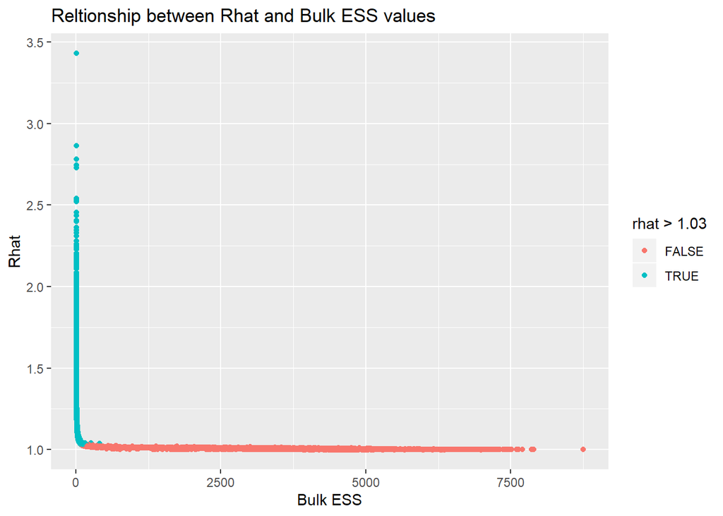

```r
data.frame( pars = names( rhat),
            rhat = rhat,
            ess_bulk = apply( posterior[,,names( rhat)], 3, ess_bulk),
            ess_tail = apply( posterior[,,names( rhat)], 3, ess_tail)) -> plotdata
rm( ess, rhat)
ggplot( plotdata) +
  geom_point( aes( x = ess_bulk, y = rhat, color = rhat > 1.03)) +
  ggtitle( 'Reltionship between Rhat and Bulk ESS values') +
  xlab( 'Bulk ESS') + ylab( 'Rhat')
```

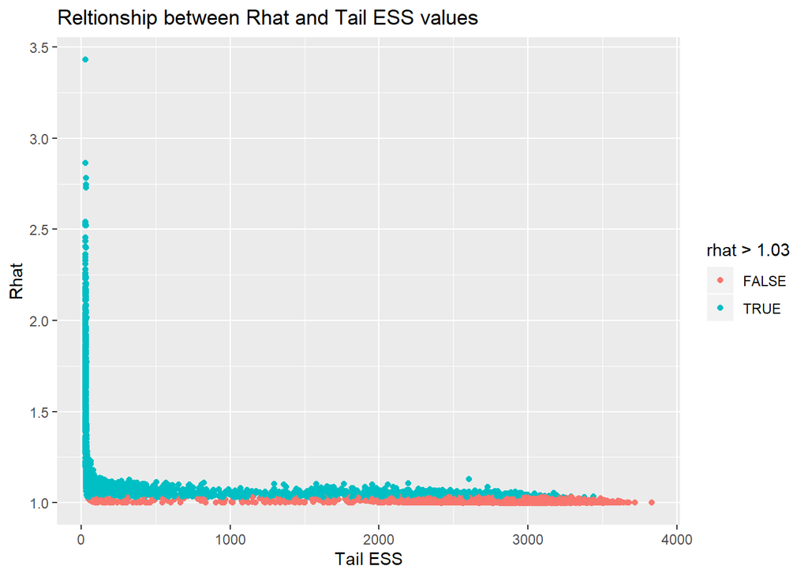

```r
ggplot( plotdata) +
  geom_point( aes( x = ess_tail, y = rhat, color = rhat > 1.03)) +
  ggtitle( 'Reltionship between Rhat and Tail ESS values') +
  xlab( 'Tail ESS') + ylab( 'Rhat')
```

$\hat{R}$ problems usually coincide with low Bulk ESS, the relationship is not as clear for Tail ESS.